# Lab 06 – Solutions: Explaining MHV Change

PAF 516

# Packages

```r
# ── Required packages ──────────────────────────────────────────────
# dplyr     - data wrangling (filter, mutate, select, group_by, summarise)
# knitr     - inline R and kable() tables
# pander    - formatted summary tables
# stargazer - regression output tables (HTML format)
# scales    - dollar() and percent() formatting
# mclust    - model-based clustering for Part 4

library( dplyr )
library( knitr )
library( pander )
library( stargazer )
library( scales )
library( mclust )
```

# Part 1 – Data

## Load and Merge LTDB Data

We load three data files from the LTDB (Longitudinal Tract Data Base): the 2000 census variables, the 2010 census variables, and tract-level metadata that includes the CBSA (metro area) name and urban/rural classification.

```r
# ── Load LTDB data files from GitHub ────────────────────────────────
URL1  <- "https://github.com/DS4PS/cpp-529-fall-2020/raw/main/LABS/data/rodeo/LTDB-2000.rds"
d1    <- readRDS( gzcon( url( URL1 ) ) )

URL2  <- "https://github.com/DS4PS/cpp-529-fall-2020/raw/main/LABS/data/rodeo/LTDB-2010.rds"
d2    <- readRDS( gzcon( url( URL2 ) ) )

URLmd <- "https://github.com/DS4PS/cpp-529-fall-2020/raw/main/LABS/data/rodeo/LTDB-META-DATA.rds"
md    <- readRDS( gzcon( url( URLmd ) ) )

# ── Remove duplicate year columns before merging ────────────────────
d1 <- select( d1, -year )
d2 <- select( d2, -year )

# ── Merge all three datasets by tract ID ────────────────────────────
# Using left_join() for tidyverse consistency (replaces base R merge())
d <- d1 %>%
  left_join( d2, by = "tractid" ) %>%
  left_join( md, by = "tractid" )

# ── Keep only urban tracts ──────────────────────────────────────────
d <- filter( d, urban == "urban" )
```

The merged dataset contains 59722 urban census tracts with variables from both the 2000 and 2010 Census.

## Construct MHV Variables

The 2000 Census reports home values in **2000 dollars** while the 2010 Census reports them in **2010 dollars**. We must adjust the 2000 values for inflation before computing change.

The CPI multiplier **1.28855** converts 2000 dollars to 2010 dollars. This is derived from the Bureau of Labor Statistics CPI-U: the annual average was 172.2 in 2000 and 218.1 in 2010. The precise multiplier (1.28855 rather than the simple ratio 218.1/172.2 = 1.2669) reflects month-to-month adjustments used in the LTDB documentation.

```r
# ── CPI inflation adjustment ───────────────────────────────────────
# Multiplier: 1.28855 converts 2000 USD to 2010 USD
# Source: BLS CPI-U, adjusted per LTDB documentation
CPI_MULTIPLIER <- 1.28855

mhv.00 <- d$mhmval00 * CPI_MULTIPLIER   # 2000 values in 2010 dollars
mhv.10 <- d$mhmval12                     # already in 2010 dollars

# ── Calculate dollar change ─────────────────────────────────────────
mhv.change <- mhv.10 - mhv.00

# ── Remove tracts with MHV below $1,000 (likely missing/invalid) ───
mhv.00[ mhv.00 < 1000 ] <- NA

# ── Calculate percent growth and cap at 200% ────────────────────────
mhv.growth <- 100 * ( mhv.change / mhv.00 )
mhv.growth[ mhv.growth > 200 ] <- NA

# ── Attach derived variables to data frame ──────────────────────────
d$mhv.00     <- mhv.00
d$mhv.10     <- mhv.10
d$mhv.change <- mhv.change
d$mhv.growth <- mhv.growth
```

## Summary Statistics

```r
df.summary <- data.frame(
  MedianHomeValue2000 = mhv.00,
  MedianHomeValue2010 = mhv.10,
  MHV.Change.00.to.10 = mhv.change,
  MHV.Growth.00.to.10 = mhv.growth
)

stargazer( df.summary,
           type   = s.type,
           digits = 0,
           summary.stat = c( "min", "p25", "median", "mean", "p75", "max" ) )
```

| Statistic | Min | Pctl(25) | Median | Mean | Pctl(75) | Max |
| --- | --- | --- | --- | --- | --- | --- |
| MedianHomeValue2000 | 1,280 | 105,661 | 154,884 | 187,119 | 224,337 | 1,288,551 |
| MedianHomeValue2010 | 9,999 | 123,200 | 193,200 | 246,570 | 312,000 | 1,000,001 |
| MHV.Change.00.to.10 | -1,228,651 | 7,187 | 36,268 | 60,047 | 94,881 | 1,000,001 |
| MHV.Growth.00.to.10 | -97 | 6 | 25 | 29 | 49 | 200 |

The median home value in 2000 (in 2010 dollars) was approximately $154,884, compared to $193,200 in 2010. The median dollar change was $36,268, and the median growth rate was 25%.

## Distribution of Home Values

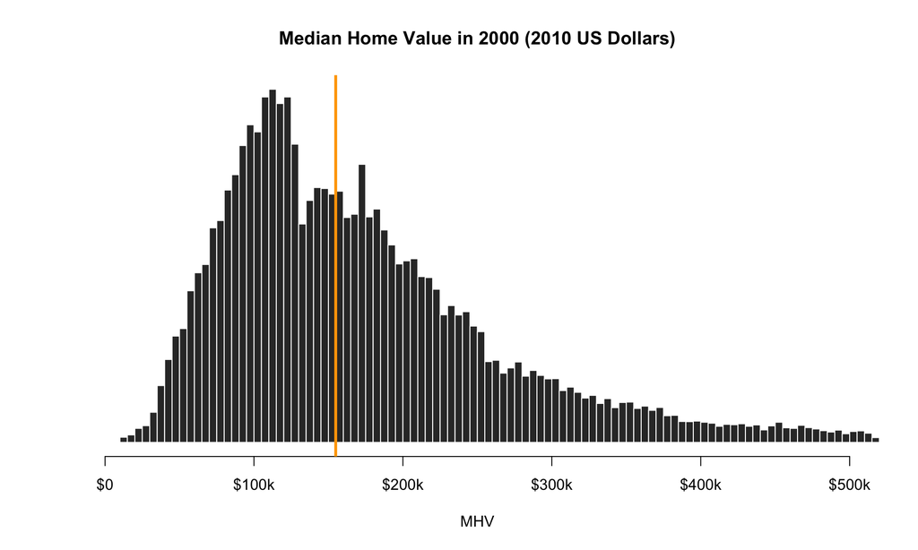

```r
hist( mhv.00, breaks = 200, xlim = c( 0, 500000 ),
      col = "gray20", border = "white",
      axes = FALSE, xlab = "MHV", ylab = "",
      main = "Median Home Value in 2000 (2010 US Dollars)" )
axis( side = 1, at = seq( 0, 500000, 100000 ),
      labels = c( "$0", "$100k", "$200k", "$300k", "$400k", "$500k" ) )
abline( v = median( mhv.00, na.rm = TRUE ), col = "orange", lwd = 3 )
```

The distribution of 2000 home values (inflation-adjusted) is right-skewed, with most tracts having median home values between $50,000 and $250,000. The orange line marks the median.

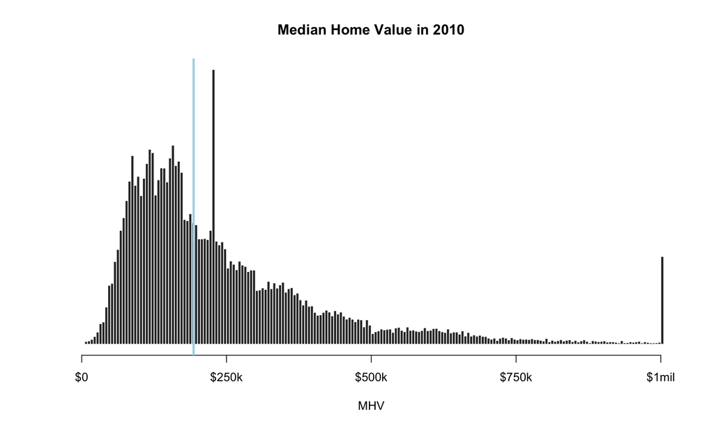

```r
hist( mhv.10, breaks = 200, xlim = c( 0, max( mhv.10, na.rm = TRUE ) ),
      col = "gray20", border = "white",
      axes = FALSE, xlab = "MHV", ylab = "",
      main = "Median Home Value in 2010" )
axis( side = 1, at = seq( 0, 1000000, 250000 ),
      labels = c( "$0", "$250k", "$500k", "$750k", "$1mil" ) )
abline( v = median( mhv.10, na.rm = TRUE ), col = "lightblue", lwd = 3 )
```

## Distribution of Changes

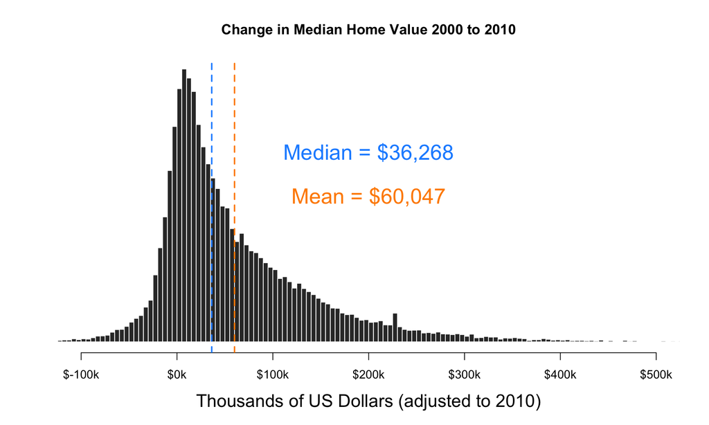

```r
hist( mhv.change / 1000, breaks = 500,
      xlim = c( -100, 500 ), yaxt = "n", xaxt = "n",
      xlab = "Thousands of US Dollars (adjusted to 2010)", cex.lab = 1.5,
      ylab = "", main = "Change in Median Home Value 2000 to 2010",
      col = "gray20", border = "white" )
axis( side = 1, at = seq( -100, 500, 100 ),
      labels = paste0( "$", seq( -100, 500, 100 ), "k" ) )

mean.x <- mean( mhv.change / 1000, na.rm = TRUE )
abline( v = mean.x, col = "darkorange", lwd = 2, lty = 2 )
text( x = 200, y = 1500,
      labels = paste0( "Mean = ", dollar( round( 1000 * mean.x, 0 ) ) ),
      col = "darkorange", cex = 1.8, pos = 3 )

median.x <- median( mhv.change / 1000, na.rm = TRUE )
abline( v = median.x, col = "dodgerblue", lwd = 2, lty = 2 )
text( x = 200, y = 2000,
      labels = paste0( "Median = ", dollar( round( 1000 * median.x, 0 ) ) ),
      col = "dodgerblue", cex = 1.8, pos = 3 )
```

Most tracts experienced positive home value changes between 2000 and 2010, though the distribution is right-skewed with a handful of tracts seeing very large gains. The mean change ($60,047) exceeds the median ($36,268), reflecting the influence of high-growth outliers.

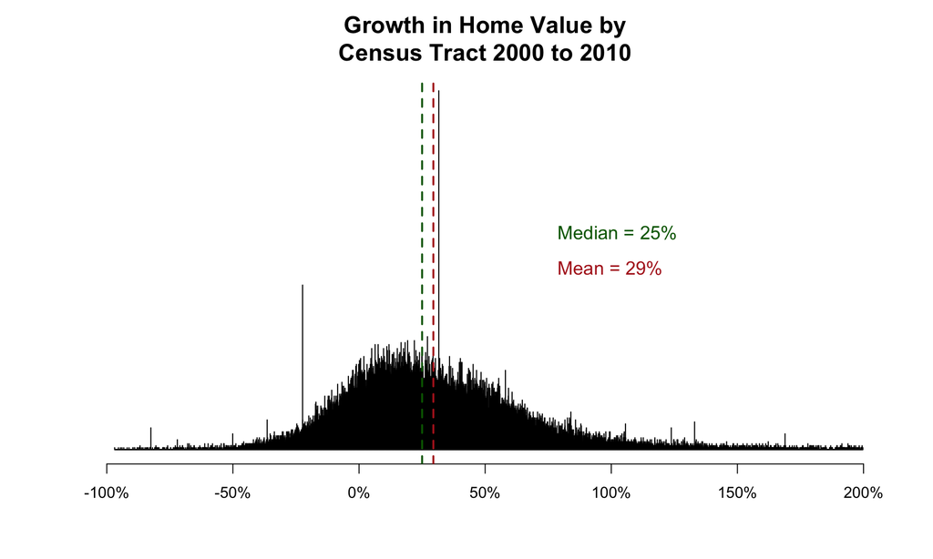

```r
hg <- hist( mhv.growth, breaks = 5000,
            xlim = c( -100, 200 ), yaxt = "n", xaxt = "n",
            xlab = "", cex.main = 1.5,
            ylab = "", main = "Growth in Home Value by\nCensus Tract 2000 to 2010",
            col = "gray40" )
axis( side = 1, at = seq( -100, 200, 50 ),
      labels = paste0( seq( -100, 200, 50 ), "%" ) )

ymax <- max( hg$count )

mean.x <- mean( mhv.growth, na.rm = TRUE )
abline( v = mean.x, col = "firebrick", lwd = 2, lty = 2 )
text( x = 75, y = ( 0.5 * ymax ),
      labels = paste0( "Mean = ", round( mean.x, 0 ), "%" ),
      col = "firebrick", cex = 1.2, pos = 4 )

median.x <- median( mhv.growth, na.rm = TRUE )
abline( v = median.x, col = "darkgreen", lwd = 2, lty = 2 )
text( x = 75, y = ( 0.6 * ymax ),
      labels = paste0( "Median = ", round( median.x, 0 ), "%" ),
      col = "darkgreen", cex = 1.2, pos = 4 )
```

The growth rate distribution is roughly centered around 25% (median), meaning the typical urban census tract saw its inflation-adjusted home value grow by about that much over the decade. Some tracts experienced decline (negative growth), while a long right tail reflects tracts with rapid appreciation.

# Part 2 – Predict MHV Change

In this section we use **2000 levels of X** – static snapshots of census tract characteristics at the start of the study period – to predict subsequent changes in MHV. This is a predictive model: we are asking whether knowing tract conditions in 2000 helps forecast home value trajectories.

## Create Predictor Variables

We select three indicators of neighborhood distress: unemployment rate, housing vacancy rate, and poverty rate. These are computed as percentages from raw counts.

```r
d <- d %>%
  mutate(
    p.unemp  = 100 * unemp00 / clf00,    # unemployment rate (2000)
    p.vacant = 100 * vac00   / hu00,      # housing vacancy rate (2000)
    pov.rate = 100 * npov00  / dpov00     # poverty rate (2000)
  )
```

## Check for Skew

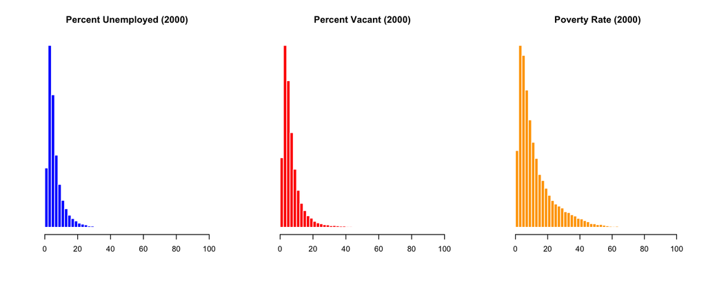

```r
par( mfrow = c( 1, 3 ) )

hist( d$p.unemp,  breaks = 50, col = "blue",   border = "white",
      yaxt = "n", xlab = "", ylab = "", main = "Percent Unemployed (2000)" )
hist( d$p.vacant, breaks = 50, col = "red",    border = "white",
      yaxt = "n", xlab = "", ylab = "", main = "Percent Vacant (2000)" )
hist( d$pov.rate, breaks = 50, col = "orange", border = "white",
      yaxt = "n", xlab = "", ylab = "", main = "Poverty Rate (2000)" )
```

```r
par( mfrow = c( 1, 1 ) )
```

All three variables are right-skewed, which is typical for rate variables that are bounded at zero. We apply a log transformation (`log( x + 1 )`) to reduce skew and stabilize variance. The `+ 1` prevents issues with zero values.

```r
# ── Log-transform to correct right skew ────────────────────────────
# Adding 1 before logging to handle zero values: log(0) is undefined
d$log.p.unemp  <- log( d$p.unemp  + 1 )
d$log.p.vacant <- log( d$p.vacant + 1 )
d$log.pov.rate <- log( d$pov.rate + 1 )
```

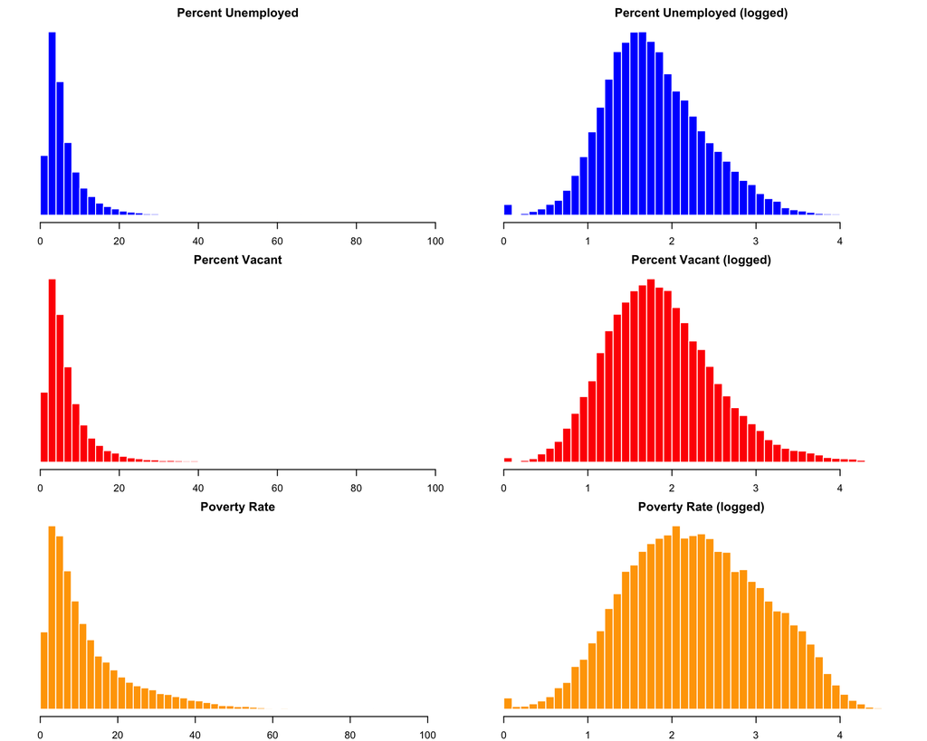

```r
par( mar = c( 2, 2, 2, 1 ) )
par( mfrow = c( 3, 2 ) )

hist( d$p.unemp,      breaks = 50, col = "blue",   border = "white",
      yaxt = "n", xlab = "", ylab = "", main = "Percent Unemployed" )
hist( d$log.p.unemp,  breaks = 50, col = "blue",   border = "white",
      yaxt = "n", xlab = "", ylab = "", main = "Percent Unemployed (logged)" )
hist( d$p.vacant,     breaks = 50, col = "red",    border = "white",
      yaxt = "n", xlab = "", ylab = "", main = "Percent Vacant" )
hist( d$log.p.vacant, breaks = 50, col = "red",    border = "white",
      yaxt = "n", xlab = "", ylab = "", main = "Percent Vacant (logged)" )
hist( d$pov.rate,     breaks = 50, col = "orange", border = "white",
      yaxt = "n", xlab = "", ylab = "", main = "Poverty Rate" )
hist( d$log.pov.rate, breaks = 50, col = "orange", border = "white",
      yaxt = "n", xlab = "", ylab = "", main = "Poverty Rate (logged)" )
```

```r
par( mfrow = c( 1, 1 ) )
```

The log transformation substantially reduces the right skew in all three variables, bringing them closer to a normal distribution. This improves the validity of OLS regression assumptions.

## Descriptive Statistics

```r
df.part2 <- data.frame(
  MHV.Change.00.to.10 = d$mhv.change,
  MHV.Growth.00.to.10 = d$mhv.growth,
  UnempLog2000        = d$log.p.unemp,
  VacantLog2000       = d$log.p.vacant,
  PovRateLog2000      = d$log.pov.rate
)

stargazer( df.part2,
           type   = s.type,
           digits = 2,
           summary.stat = c( "min", "p25", "median", "mean", "p75", "max" ) )
```

| Statistic | Min | Pctl(25) | Median | Mean | Pctl(75) | Max |
| --- | --- | --- | --- | --- | --- | --- |
| MHV.Change.00.to.10 | -1,228,651.00 | 7,186.68 | 36,267.80 | 60,046.97 | 94,881.29 | 1,000,001.00 |
| MHV.Growth.00.to.10 | -96.89 | 5.74 | 25.00 | 29.46 | 48.73 | 199.74 |
| UnempLog2000 | 0.00 | 1.37 | 1.72 | 1.78 | 2.15 | 4.62 |
| VacantLog2000 | 0.00 | 1.41 | 1.81 | 1.86 | 2.25 | 4.62 |
| PovRateLog2000 | 0.00 | 1.69 | 2.25 | 2.28 | 2.87 | 4.62 |

## Correlation Plot

We check for multicollinearity among the three predictors. We take a random sample of 5,000 observations for faster plotting.

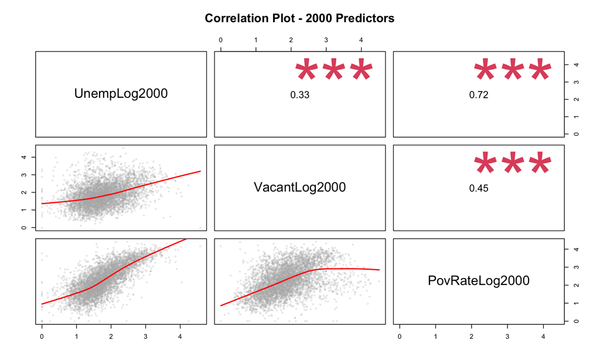

```r
set.seed( 1234 )
# slice_sample() replaces the deprecated sample_n()
plotd2 <- df.part2 %>% na.omit() %>% slice_sample( n = 5000 )

# ── Custom panel functions for pairs() ─────────────────────────────
panel.cor <- function( x, y, digits = 2, prefix = "", cex.cor ) {
  usr <- par( "usr" ); on.exit( par( usr ) )
  par( usr = c( 0, 1, 0, 1 ) )
  r   <- abs( cor( x, y, use = "complete.obs" ) )
  txt <- format( c( r, 0.123456789 ), digits = digits )[1]
  txt <- paste( prefix, txt, sep = "" )
  if ( missing( cex.cor ) ) cex <- 0.8 / strwidth( txt )
  test <- cor.test( x, y )
  Signif <- symnum( test$p.value, corr = FALSE, na = FALSE,
                    cutpoints = c( 0, 0.001, 0.01, 0.05, 0.1, 1 ),
                    symbols   = c( "***", "**", "*", ".", " " ) )
  text( 0.5, 0.5, txt, cex = 1.5 )
  text( .7, .8, Signif, cex = cex, col = 2 )
}

panel.smooth <- function( x, y, col = par( "col" ), bg = NA,
                          pch = par( "pch" ), cex = 0.5,
                          col.smooth = "red", span = 2/3, iter = 3, ... ) {
  points( x, y, pch = 19, col = gray( 0.7, 0.2 ), bg = bg, cex = cex )
  ok <- is.finite( x ) & is.finite( y )
  if ( any( ok ) )
    lines( stats::lowess( x[ok], y[ok], f = span, iter = iter ),
           col = col.smooth, lwd = 2, ... )
}

pairs( plotd2[ , c( "UnempLog2000", "VacantLog2000", "PovRateLog2000" ) ],
       upper.panel = panel.cor,
       lower.panel = panel.smooth,
       main = "Correlation Plot - 2000 Predictors" )
```

## Regression Models

We run two models: one predicting dollar change in MHV and one predicting percent growth.

```r
m1 <- lm( mhv.change ~ log.p.unemp + log.p.vacant + log.pov.rate, data = d )
m2 <- lm( mhv.growth ~ log.p.unemp + log.p.vacant + log.pov.rate, data = d )

stargazer( m1, m2,
           type = s.type,
           digits = 2,
           omit.stat = c( "rsq", "f" ),
           covariate.labels = c( "Unemployment Rate (log)",
                                 "Vacancy Rate (log)",
                                 "Poverty Rate (log)" ),
           dep.var.labels = c( "MHV Change ($)", "MHV Growth (%)" ),
           title = "Part 2: Predicting MHV Change Using 2000 Levels of X" )
```

**Part 2: Predicting MHV Change Using 2000 Levels of X**

|  | *Dependent variable:* |  |
| --- | --- | --- |
|  | MHV Change () | MHV Growth (%) |
|  | (1) | (2) |
| Unemployment Rate (log) | 2,520.75*** | 2.63*** |
|  | (906.44) | (0.36) |
| Vacancy Rate (log) | -19,154.45*** | -2.59*** |
|  | (633.99) | (0.25) |
| Poverty Rate (log) | 2,939.64*** | 5.13*** |
|  | (709.92) | (0.28) |
| Constant | 84,466.43*** | 17.94*** |
|  | (1,389.90) | (0.54) |
| Observations | 59,497 | 58,784 |
| Adjusted R<sup>2</sup> | 0.02 | 0.02 |
| Residual Std. Error | 89,833.66 (df = 59493) | 34.84 (df = 58780) |
| *Note:* | *p<0.1; **p<0.05;*** p<0.01 |  |

# Part 3 – Explain MHV Change

Now we shift from prediction to explanation. Instead of using 2000 levels of X, we use **changes in X** from 2000 to 2010 to explain changes in MHV over the same period. This change-based specification moves us closer to causal inference because it controls for time-invariant unobserved characteristics of each tract.

## Create Change Variables

```r
# ── Compute 2010 versions of the same three indicators ──────────────
d <- d %>%
  mutate(
    p.unemp10  = 100 * unemp12 / clf12,    # unemployment rate (~2010)
    p.vacant10 = 100 * vac10   / hu10,      # vacancy rate (2010)
    pov.rate10 = 100 * npov12  / dpov12     # poverty rate (~2010)
  )

# ── Log-transform 2010 variables (same transformation as 2000) ──────
d$log.p.unemp10  <- log( d$p.unemp10  + 1 )
d$log.p.vacant10 <- log( d$p.vacant10 + 1 )
d$log.pov.rate10 <- log( d$pov.rate10 + 1 )

# ── Compute changes (2010 value minus 2000 value) ───────────────────
# Positive values = increase; negative values = decrease
d$ch.log.unemp  <- d$log.p.unemp10  - d$log.p.unemp
d$ch.log.vacant <- d$log.p.vacant10 - d$log.p.vacant
d$ch.log.povrat <- d$log.pov.rate10 - d$log.pov.rate
```

## Distribution of Change Variables

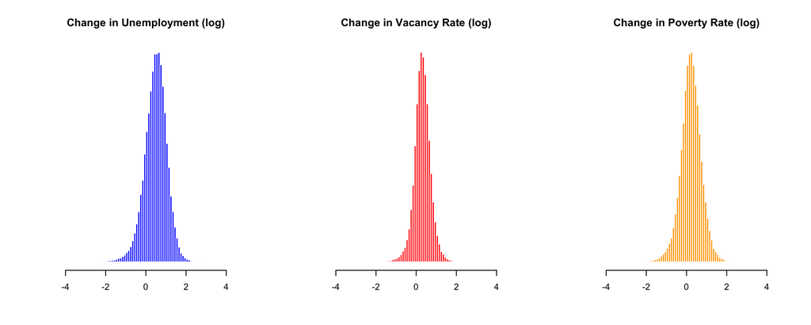

```r
par( mfrow = c( 1, 3 ) )

hist( d$ch.log.unemp,  breaks = 100, col = "blue",   border = "white",
      yaxt = "n", xlab = "", ylab = "", main = "Change in Unemployment (log)" )
hist( d$ch.log.vacant, breaks = 100, col = "red",    border = "white",
      yaxt = "n", xlab = "", ylab = "", main = "Change in Vacancy Rate (log)" )
hist( d$ch.log.povrat, breaks = 100, col = "orange", border = "white",
      yaxt = "n", xlab = "", ylab = "", main = "Change in Poverty Rate (log)" )
```

```r
par( mfrow = c( 1, 1 ) )
```

The change variables are approximately normally distributed and centered near zero, which is a desirable property for regression analysis. Most tracts saw modest changes in all three indicators, with a minority experiencing large shifts in either direction.

## Descriptive Statistics

```r
df.part3 <- data.frame(
  MHV.Change.00.to.10 = d$mhv.change,
  MHV.Growth.00.to.10 = d$mhv.growth,
  Ch.Unemp.Log        = d$ch.log.unemp,
  Ch.Vacant.Log       = d$ch.log.vacant,
  Ch.PovRate.Log      = d$ch.log.povrat
)

stargazer( df.part3,
           type   = s.type,
           digits = 2,
           summary.stat = c( "min", "p25", "median", "mean", "p75", "max" ) )
```

| Statistic | Min | Pctl(25) | Median | Mean | Pctl(75) | Max |
| --- | --- | --- | --- | --- | --- | --- |
| MHV.Change.00.to.10 | -1,228,651.00 | 7,186.68 | 36,267.80 | 60,046.97 | 94,881.29 | 1,000,001.00 |
| MHV.Growth.00.to.10 | -96.89 | 5.74 | 25.00 | 29.46 | 48.73 | 199.74 |
| Ch.Unemp.Log | -4.62 | 0.15 | 0.51 | 0.48 | 0.85 | 4.62 |
| Ch.Vacant.Log | -4.62 | 0.07 | 0.31 | 0.30 | 0.55 | 4.62 |
| Ch.PovRate.Log | -4.62 | -0.09 | 0.22 | 0.22 | 0.54 | 4.62 |

## Correlation Plot

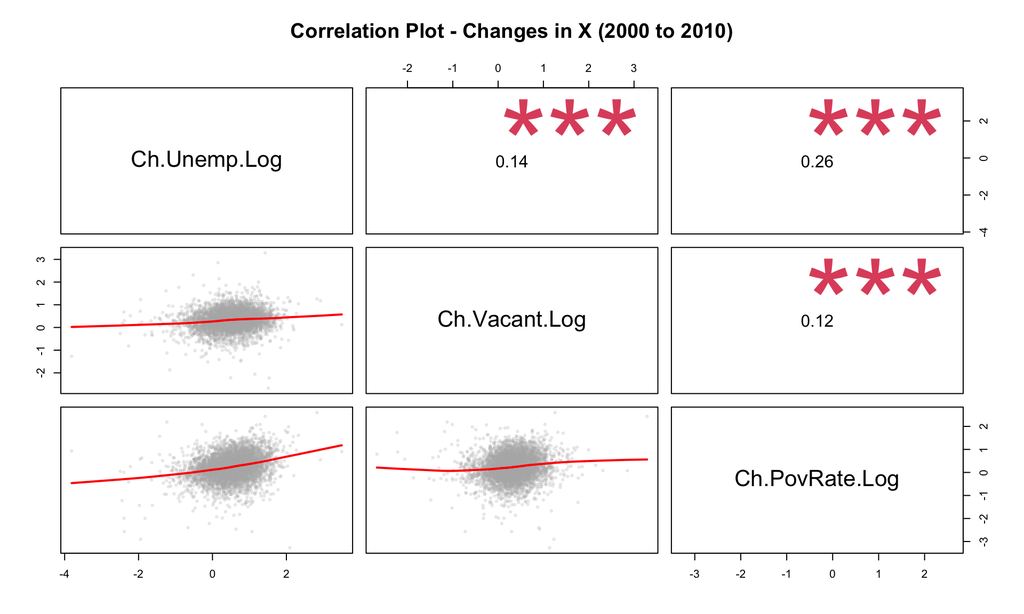

```r
set.seed( 1234 )
# slice_sample() replaces the deprecated sample_n()
plotd3 <- df.part3 %>% na.omit() %>% slice_sample( n = 5000 )

pairs( plotd3[ , c( "Ch.Unemp.Log", "Ch.Vacant.Log", "Ch.PovRate.Log" ) ],
       upper.panel = panel.cor,
       lower.panel = panel.smooth,
       main = "Correlation Plot - Changes in X (2000 to 2010)" )
```

The correlations among the change variables tend to be lower than among the level variables. This is common: tracts that are jointly distressed (high levels of unemployment, vacancy, and poverty) may experience different trajectories in each dimension over time.

## Regression Models

```r
m3 <- lm( mhv.change ~ ch.log.unemp + ch.log.vacant + ch.log.povrat, data = d )
m4 <- lm( mhv.growth ~ ch.log.unemp + ch.log.vacant + ch.log.povrat, data = d )

stargazer( m3, m4,
           type = s.type,
           digits = 2,
           omit.stat = c( "rsq", "f" ),
           covariate.labels = c( "Change in Unemployment (log)",
                                 "Change in Vacancy Rate (log)",
                                 "Change in Poverty Rate (log)" ),
           dep.var.labels = c( "MHV Change ($)", "MHV Growth (%)" ),
           title = "Part 3: Explaining MHV Change Using Changes in X" )
```

**Part 3: Explaining MHV Change Using Changes in X**

|  | *Dependent variable:* |  |
| --- | --- | --- |
|  | MHV Change () | MHV Growth (%) |
|  | (1) | (2) |
| Change in Unemployment (log) | -10,958.57*** | -7.44*** |
|  | (664.96) | (0.26) |
| Change in Vacancy Rate (log) | 3,603.86*** | -4.61*** |
|  | (870.88) | (0.34) |
| Change in Poverty Rate (log) | -35,404.69*** | -15.20*** |
|  | (708.04) | (0.27) |
| Constant | 71,855.34*** | 37.80*** |
|  | (528.99) | (0.21) |
| Observations | 59,212 | 58,561 |
| Adjusted R<sup>2</sup> | 0.05 | 0.09 |
| Residual Std. Error | 87,520.65 (df = 59208) | 33.44 (df = 58557) |
| *Note:* | *p<0.1; **p<0.05;*** p<0.01 |  |

The coefficients now have a different interpretation than in Part 2:

## Side-by-Side Comparison: Levels vs. Changes

```r
stargazer( m1, m3,
           type = s.type,
           digits = 2,
           omit.stat = c( "rsq", "f" ),
           column.labels = c( "2000 Levels (Predict)", "Changes in X (Explain)" ),
           dep.var.labels = "MHV Change ($)",
           title = "Part 2 vs Part 3: Levels vs Changes (Dollar Change)" )
```

**Part 2 vs Part 3: Levels vs Changes (Dollar Change)**

|  | *Dependent variable:* |  |
| --- | --- | --- |
|  | MHV Change () |  |
|  | 2000 Levels (Predict) | Changes in X (Explain) |
|  | (1) | (2) |
| log.p.unemp | 2,520.75*** |  |
|  | (906.44) |  |
| log.p.vacant | -19,154.45*** |  |
|  | (633.99) |  |
| log.pov.rate | 2,939.64*** |  |
|  | (709.92) |  |
| ch.log.unemp |  | -10,958.57*** |
|  |  | (664.96) |
| ch.log.vacant |  | 3,603.86*** |
|  |  | (870.88) |
| ch.log.povrat |  | -35,404.69*** |
|  |  | (708.04) |
| Constant | 84,466.43*** | 71,855.34*** |
|  | (1,389.90) | (528.99) |
| Observations | 59,497 | 59,212 |
| Adjusted R<sup>2</sup> | 0.02 | 0.05 |
| Residual Std. Error | 89,833.66 (df = 59493) | 87,520.65 (df = 59208) |
| *Note:* | *p<0.1; **p<0.05;*** p<0.01 |  |

```r
stargazer( m2, m4,
           type = s.type,
           digits = 2,
           omit.stat = c( "rsq", "f" ),
           column.labels = c( "2000 Levels (Predict)", "Changes in X (Explain)" ),
           dep.var.labels = "MHV Growth (%)",
           title = "Part 2 vs Part 3: Levels vs Changes (Growth Rate)" )
```

**Part 2 vs Part 3: Levels vs Changes (Growth Rate)**

|  | *Dependent variable:* |  |
| --- | --- | --- |
|  | MHV Growth (%) |  |
|  | 2000 Levels (Predict) | Changes in X (Explain) |
|  | (1) | (2) |
| log.p.unemp | 2.63*** |  |
|  | (0.36) |  |
| log.p.vacant | -2.59*** |  |
|  | (0.25) |  |
| log.pov.rate | 5.13*** |  |
|  | (0.28) |  |
| ch.log.unemp |  | -7.44*** |
|  |  | (0.26) |
| ch.log.vacant |  | -4.61*** |
|  |  | (0.34) |
| ch.log.povrat |  | -15.20*** |
|  |  | (0.27) |
| Constant | 17.94*** | 37.80*** |
|  | (0.54) | (0.21) |
| Observations | 58,784 | 58,561 |
| Adjusted R<sup>2</sup> | 0.02 | 0.09 |
| Residual Std. Error | 34.84 (df = 58780) | 33.44 (df = 58557) |
| *Note:* | *p<0.1; **p<0.05;*** p<0.01 |  |

**Key Comparison:** The change-based models (Part 3) often explain more variance than the level-based models (Part 2), as reflected in the adjusted R-squared values. The change in model fit between the two specifications demonstrates the value of a panel-like approach: by focusing on within-tract changes over time, we reduce omitted variable bias and get coefficients that are more plausibly interpretable as causal effects.

In some cases, a variable may be a strong predictor in Part 2 (high levels of X predict MHV decline) but have a weaker or different relationship in Part 3 (changes in X are less related to MHV change). This pattern suggests the variable was serving as a proxy for other correlated factors in the cross-sectional model rather than being a true driver of change.